# Name : Samarth Deshpande

# Plot the ROC Curve and print the AUC of the model on the test set. Comment on the quality of the model performance as seen in the ROC curve

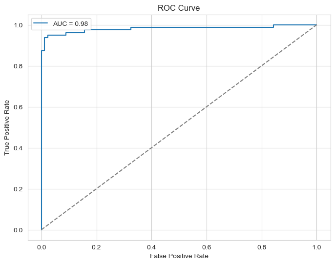

```
AUC: 0.9810837718674442
```

```python
from sklearn.metrics import roc_curve, roc_auc_score
import matplotlib.pyplot as plt

# Predict probabilities for the positive class
y_prob = logistic_regression_model.predict_proba(X_test)[:, 1]

# Compute ROC curve and AUC
fpr, tpr, thresholds = roc_curve(y_test, y_prob)
auc = roc_auc_score(y_test, y_prob)

# Plot ROC Curve
plt.figure(figsize=(8, 6))
plt.plot(fpr, tpr, label=f'AUC = {auc:.2f}')
plt.plot([0, 1], [0, 1], linestyle='--', color='gray')
plt.title('ROC Curve')
plt.xlabel('False Positive Rate')
plt.ylabel('True Positive Rate')
plt.legend()
plt.show()

print("AUC:", auc)
```

# Model's ability to separate the classes and make accurate predictions is quite strong, with 98.1% accuracy in terms of the AUC.

```python
# Predictions for knn
y_pred_knn = knn_model.predict(X_test)
knn_cv_scores = cross_val_score(knn_model, X_train, y_train, cv=5)

# Predictions for svm
y_pred_svm = svm_model.predict(X_test)
svm_cv_scores = cross_val_score(svm_model, X_train, y_train, cv=5)

# Calculate metrics for knn
knn_accuracy = accuracy_score(y_test, y_pred_knn)
knn_precision = precision_score(y_test, y_pred_knn)
knn_recall = recall_score(y_test, y_pred_knn)
knn_f1 = f1_score(y_test, y_pred_knn)

# Calculate metrics for SVM
svm_accuracy = accuracy_score(y_test, y_pred_svm)
svm_precision = precision_score(y_test, y_pred_svm)
svm_recall = recall_score(y_test, y_pred_svm)
svm_f1 = f1_score(y_test, y_pred_svm)

# Print the scores for knn
print("KNN Metrics:")
print("Accuracy:", knn_accuracy)
print("Precision:", knn_precision)
print("Recall:", knn_recall)
print("F1-Score:", knn_f1)
print("Cross-Validation Scores:", knn_cv_scores)

# Print the scores for SVM
print("\nSVM Metrics:")
print("Accuracy:", svm_accuracy)
print("Precision:", svm_precision)
print("Recall:", svm_recall)
print("F1-Score:", svm_f1)
print("Cross-Validation Scores:", svm_cv_scores)
```

```
KNN Metrics:
Accuracy: 0.9166666666666666
Precision: 0.9333333333333333
Recall: 0.8860759493670886
F1-Score: 0.9090909090909091
Cross-Validation Scores: [0.91111111 0.92537313 0.93283582 0.88059701 0.93283582]

SVM Metrics:
Accuracy: 0.9583333333333334
Precision: 0.9864864864864865
Recall: 0.9240506329113924
F1-Score: 0.954248366013072
Cross-Validation Scores: [0.91851852 0.94776119 0.94029851 0.91044776 0.94029851]
```

# Inferences

# SVM and Logistic Regression perform similarly in terms of accuracy.

# SVM and Logistic Regression have better precision, suggesting fewer false positives.

# Logistic Regression and SVM perform better in capturing positive instances.

# SVM and Logistic Regression achieve a better balance between precision and recall.

# SVM consistently outperforms KNN and has comparable performance to Logistic Regression in cross-validation.